# Initalization

```python
!pip install stargazer
```

```python
import pandas as pd
import numpy as np
import sys
import re
import matplotlib.pyplot as plt
import seaborn as sns
from scipy.stats import ks_2samp
import statsmodels.api as sm
import statsmodels.formula.api as smf
from sklearn.linear_model import LinearRegression
from stargazer.stargazer import Stargazer
from IPython.display import display, HTML
from IPython.display import display, Latex
```

```python
! git clone https://github.com/AndriyBilinskiy/Econometrics-Project cloned_repo
```

```
Cloning into 'cloned_repo'...
remote: Enumerating objects: 9, done.
remote: Counting objects: 100% (9/9), done.
remote: Compressing objects: 100% (9/9), done.
remote: Total 9 (delta 3), reused 0 (delta 0), pack-reused 0
Unpacking objects: 100% (9/9), 2.38 MiB | 6.10 MiB/s, done.
```

```python
np.set_printoptions(threshold=sys.maxsize)
```

```python
df = pd.read_csv("/content/cloned_repo/Levels_Fyi_Salary_Data.csv")
```

```python
df['timestamp'] = pd.to_datetime(df['timestamp'])
```

# Data Analysis

After exploring the data that is in the dataset, you need to sort it by date, since it is stored a little randomly.

```python
df['timestamp'] = np.sort(df['timestamp'])
```

```python
columns_ = ['timestamp', 'company', 'title', 'totalyearlycompensation',
       'location', 'yearsofexperience', 'yearsatcompany', 'gender', 'Masters_Degree', 'Bachelors_Degree', 'Doctorate_Degree',
       'Highschool', 'Some_College', 'Race_Asian', 'Race_White',
       'Race_Two_Or_More', 'Race_Black', 'Race_Hispanic', 'Race', 'Education']
df = df[columns_]
```

Data explenation:

- timestamp - date when the current record was created
- company - the name of the company where the employee works
- title - the name of the job position
- totalyearlycompensation - the employee's annual compensation
- location - the city where the employee works
- yearsofexperience - the employee's total number of years in commercial business
- yearsatcompany - the number of years the employee workes in this company
- gender - employee's gender
- Race - employee's race
- Education - education level of employee (high school, bachelor etc.)
- Masters_Degree/Bachelors_Degree/Doctorate_Degree/Highschool/Some_College - dummy variables which show all educational achievements of the employee
- Race_Asian/White/Two_Or_More/Black/Hispanic - dummy variables which show the race to which the employee belongs

In this research we decided to work with only USA, becuase data contains a lot of "NA's" and it will significantly impact the results of the model, also situation with income massively depend on employee`s location (different country - different salaries, economy etc.)

```python
pattern = r"^(?!.*,.*,).*$"
USA_paterned = [element for element in df['location'].unique() if re.search(pattern, element)]
USA = [element for element in USA_paterned if len(element.split(',')) == 2]
```

```python
df = df[df['location'].isin(USA)]
len(df.location.unique())
```

```
717
```

```python
df.head()
```

|  | timestamp | company | title | totalyearlycompensation | location | yearsofexperience | yearsatcompany | gender | Masters_Degree | Bachelors_Degree | Doctorate_Degree | Highschool | Some_College | Race_Asian | Race_White | Race_Two_Or_More | Race_Black | Race_Hispanic | Race | Education |
| --- | --- | --- | --- | --- | --- | --- | --- | --- | --- | --- | --- | --- | --- | --- | --- | --- | --- | --- | --- | --- |
| 0 | 2017-06-07 11:33:27 | Oracle | Product Manager | 127000 | Redwood City, CA | 1.5 | 1.5 | NaN | 0 | 0 | 0 | 0 | 0 | 0 | 0 | 0 | 0 | 0 | NaN | NaN |
| 1 | 2017-06-10 17:11:29 | eBay | Software Engineer | 100000 | San Francisco, CA | 5.0 | 3.0 | NaN | 0 | 0 | 0 | 0 | 0 | 0 | 0 | 0 | 0 | 0 | NaN | NaN |
| 2 | 2017-06-11 14:53:57 | Amazon | Product Manager | 310000 | Seattle, WA | 8.0 | 0.0 | NaN | 0 | 0 | 0 | 0 | 0 | 0 | 0 | 0 | 0 | 0 | NaN | NaN |
| 3 | 2017-06-14 21:22:25 | Apple | Software Engineering Manager | 372000 | Sunnyvale, CA | 7.0 | 5.0 | NaN | 0 | 0 | 0 | 0 | 0 | 0 | 0 | 0 | 0 | 0 | NaN | NaN |
| 4 | 2017-06-16 10:44:01 | Microsoft | Software Engineer | 157000 | Mountain View, CA | 5.0 | 3.0 | NaN | 0 | 0 | 0 | 0 | 0 | 0 | 0 | 0 | 0 | 0 | NaN | NaN |

Our topic for interest for this observation is a *totalyearlycompensation* difference for male, female and its change before, after the Covid. *yearsofexperience*, as you will see later is higly significant for our prediction model so wiil drop *totalyearlycompensation* and *yearsofexperience* outliers from your dataset to make it representative and easy to generalise.

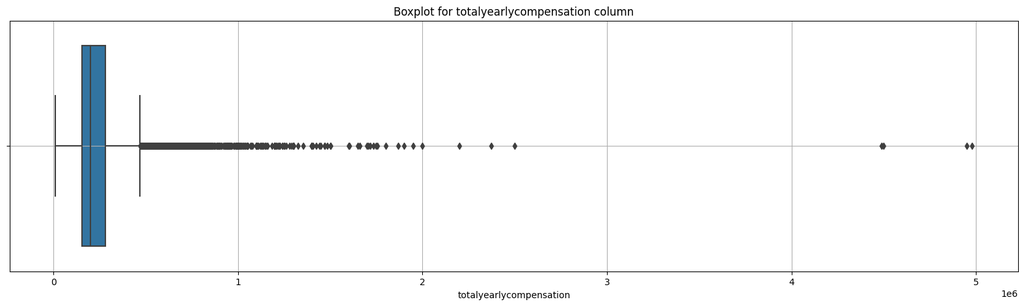

```python
plt.figure(figsize=(20, 5))
sns.boxplot(x=df['totalyearlycompensation'])
plt.title('Boxplot for totalyearlycompensation column')
plt.grid()
plt.show()
```

```python
def remove_outliers():
    q1 = df['totalyearlycompensation'].quantile(0.25)
    q3 = df['totalyearlycompensation'].quantile(0.75)
    iqr = q3-q1
    left_boundary = q1 - 1.5*iqr
    right_boundary = q3 + 1.5*iqr
    df_pre = df[(df['totalyearlycompensation'] > left_boundary)\
                    & (df['totalyearlycompensation'] < right_boundary)]

    q1 = df_pre['yearsofexperience'].quantile(0.25)
    q3 = df_pre['yearsofexperience'].quantile(0.75)
    iqr = q3-q1
    left_boundary = q1 - 1.5*iqr
    right_boundary = q3 + 1.5*iqr
    df_out = df_pre[(df_pre['yearsofexperience'] > left_boundary)\
                    & (df_pre['yearsofexperience'] < right_boundary)]

    return df_out
```

```python
df = remove_outliers()
```

# Gender Discrimination

## Gender distribution

```python
df['gender'].unique()
```

```
array([nan, 'Male', 'Female', 'Other', 'Title: Senior Software Engineer'],
      dtype=object)
```

```python
df = df[df.gender != 'Title: Senior Software Engineer']
```

```python
df = df.fillna({'gender':'Unknown'})
```

```python
gender_counts = df["gender"].value_counts()
gender_counts
```

```
Male       26893
Unknown    15725
Female      6038
Other        318
Name: gender, dtype: int64
```

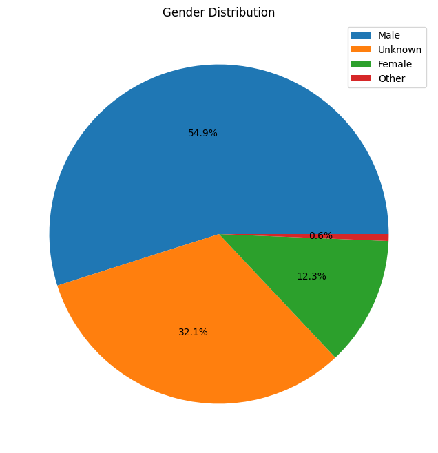

```python
gender_counts = dict(gender_counts)

genders = list(gender_counts.keys())
counts = list(gender_counts.values())

plt.figure(figsize=(8, 8))
plt.pie(counts, labels=['']*len(genders), autopct='%1.1f%%')

plt.legend(genders, loc="upper right")
plt.title("Gender Distribution")
plt.show()
```

From the pie chart above, men take majority of distribution. Since we are observing salary dispercity between male and female - we are ommiting other genders and dropping rows with NA(Unknown)

## Salary Distribution

```python
# drop unnecessary rows
df = df[df.gender.isin(('Unknown','Other')) == False]
df = df[df['Education'].notna()]
```

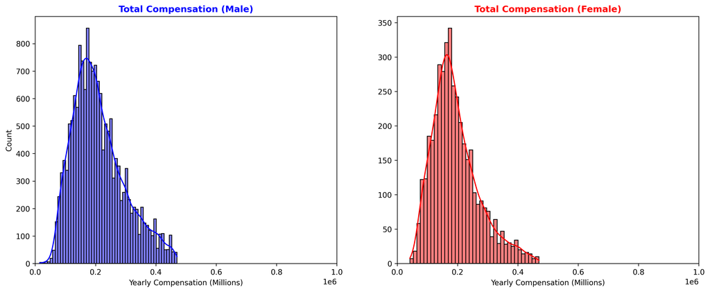

```python
fig, (ax1, ax2) = plt.subplots(1, 2, figsize=(16,6), dpi=300)
sns.histplot(df[df['gender']=='Male'].totalyearlycompensation.round(0), ax=ax1, color="blue", kde=True, linewidth=1).set(xlim=(0, 1e6))
sns.histplot(df[df['gender']=='Female'].totalyearlycompensation.round(0), ax=ax2, color="red", kde=True, linewidth=1).set(xlim=(0, 1e6))
ax1.set_title("Total Compensation (Male)", fontweight="bold", color="blue")
ax1.set_xlabel('Yearly Compensation (Millions)')
ax2.set_title("Total Compensation (Female)", fontweight="bold", color="red")
ax2.set_xlabel('Yearly Compensation (Millions)')
ax2.set_ylabel('');
```

```python
df[df['gender']=='Male'].totalyearlycompensation.skew()
```

```
0.7374978470491212
```

```python
df[df['gender']=='Female'].totalyearlycompensation.skew()
```

```
0.9343402956152327
```

**Kolmogorov-Smirnov test**

- The null hypothesis is that distributions are equal $F(X)=G(X)$
- The two sided alternative is that $F(X)≠G(X)$
- The one sided 'less' alternative is that $F(X)<G(X)$
- The one sided 'greater' alternative is $F(X)>G(X)$

$F(x)$ represent the gender=Male group and the distribution $G(x)$ will represent the gender=Female group. If the two sided test finds a significant p value, a follow up one sided test will be performed to see which distribution has the greater area under the curve for a given salary x

```python
def run_ks_test(ser1, ser2):
    alternatives = ['F(x) != G(X)', 'F(x) < G(x)', 'F(x) > G(x)']
    p1 = ks_2samp(ser1, ser2).pvalue
    p2 = ks_2samp(ser1, ser2, alternative='less').pvalue
    p3 = ks_2samp(ser1, ser2, alternative='greater').pvalue
    tests = [round(p1, 5), round(p2, 5), round(p3,5)]

    output_df = pd.DataFrame({'Test': alternatives,
                  'P-value': tests})
    return output_df

run_ks_test(df[df['gender']=='Male'].totalyearlycompensation, df[df['gender']=='Female'].totalyearlycompensation)
```

|  | Test | P-value |
| --- | --- | --- |
| 0 | F(x) != G(X) | 0.00000 |
| 1 | F(x) < G(x) | 0.00000 |
| 2 | F(x) > G(x) | 0.99448 |

Consequently, we reject the null hypothesis that these distributions are equal. As a follow up test we check to see which side of the test is significant.

The significant p-value for the one sided 'less' alternative indicates that for overall total compensation of Male and Female, $F(x)<G(x)$

## Salary Dispercity

```python
df[df['gender'] == 'Male'].totalyearlycompensation.mean().round()
```

```
210532.0
```

```python
df[df['gender'] == 'Female'].totalyearlycompensation.mean().round()
```

```
193719.0
```

```python
((df[df['gender'] == 'Male'].totalyearlycompensation.mean() - \
    df[df['gender'] == 'Female'].totalyearlycompensation.mean()) \
         / \
        df[df['gender'] == 'Male'].totalyearlycompensation.mean()).round(3) * 100
```

```
8.0
```

If we compare the difference between men's and women's salaries in general, it can be seen that the difference in average incomes, which is %$8$, is in favor of men. Now we want to check whether there is a difference depending on the company, job titles or the location where the employee works.

### Top 5 companies

```python
top_companies = df["company"].value_counts().head()
top_companies
```

```
Amazon       2584
Microsoft    1626
Google       1335
Facebook      933
Apple         715
Name: company, dtype: int64
```

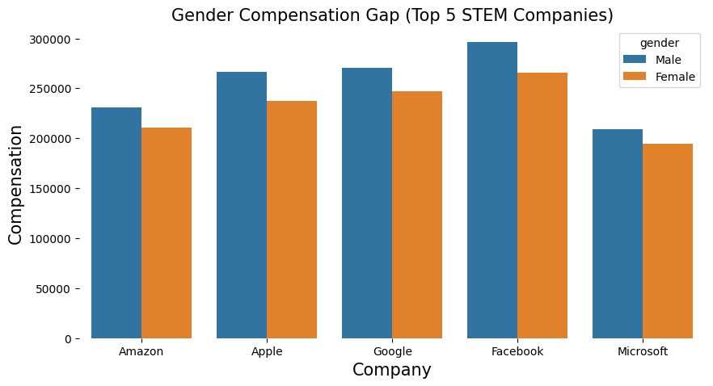

```
Average compensation gap by company:

Amazon : 19894
Apple : 29382
Google : 23217
Facebook : 30721
Microsoft : 14217
```

```python
df_top5 = df[df.company.isin(['Amazon','Microsoft','Google','Facebook','Apple'])]

plt.figure(figsize=(10, 5))
sns.barplot(x="company", y="totalyearlycompensation", hue="gender", data=df_top5, errorbar=('ci', 0))
plt.title("Gender Compensation Gap (Top 5 STEM Companies)", size=15)
plt.xlabel("Company", size=15)
plt.ylabel("Compensation", size=15)
plt.xticks(fontsize=10)
sns.despine(left = True, bottom = True)
plt.show()

print("\nAverage compensation gap by company:\n")

for spec_company in df_top5.company.unique():
    difference = (df_top5[(df_top5.company == spec_company) & (df_top5.gender == 'Male')].totalyearlycompensation.mean()) - \
                    (df_top5[(df_top5.company == spec_company) & (df_top5.gender == 'Female')].totalyearlycompensation.mean())
    print(f'{spec_company} : {int(difference.round())}')
```

### Top 10 job titles

```python
top_titles = df["title"].value_counts().head(10)
top_titles
```

```
Software Engineer               12891
Product Manager                  1546
Data Scientist                    998
Hardware Engineer                 898
Software Engineering Manager      748
Product Designer                  608
Technical Program Manager         589
Management Consultant             429
Business Analyst                  388
Marketing                         329
Name: title, dtype: int64
```

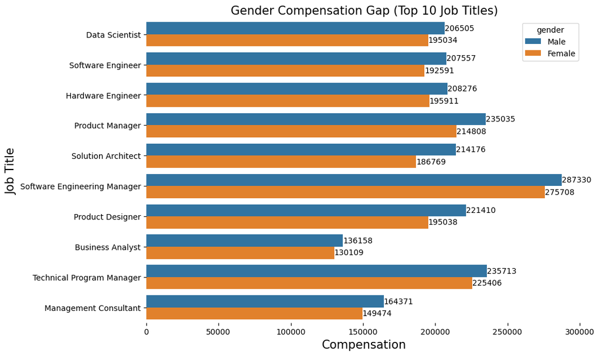

```
Average compensation gap by job title:

Data Scientist : 11471
Software Engineer : 14966
Hardware Engineer : 12365
Product Manager : 20227
Solution Architect : 27406
Software Engineering Manager : 11621
Product Designer : 26373
Business Analyst : 6048
Technical Program Manager : 10307
Management Consultant : 14898
```

```python
df_top10 = df[df.title.isin(('Software Engineer','Product Manager','Software Engineering Manager'\
                             ,'Data Scientist','Hardware Engineer', 'Product Designer','Technical Program Manager','Solution Architect'\
                             ,'Management Consultant','Business Analyst'))]

plt.figure(figsize=(10, 7))
ax = sns.barplot(x="totalyearlycompensation", y="title", hue="gender", data=df_top10, errorbar=('ci', 0))
for container in ax.containers:
    ax.bar_label(container, fmt='%.f')
plt.title("Gender Compensation Gap (Top 10 Job Titles)", size=15)
plt.xlabel("Compensation", size=15)
plt.ylabel("Job Title", size=15)
plt.xticks(fontsize=10)
sns.despine(left = True, bottom = True)
plt.show()


print("\nAverage compensation gap by job title:\n")

for spec_title in df_top10.title.unique():
    difference = (df_top10[(df_top10.title == spec_title) & (df_top10.gender == 'Male')].totalyearlycompensation.mean()) - \
                    (df_top10[(df_top10.title == spec_title) & (df_top10.gender == 'Female')].totalyearlycompensation.mean())
    print(f'{spec_title} : {int(difference.round())}')
```

### Top 15 locations

```python
top_locations = df["location"].value_counts().head(15)
top_locations
```

```
Seattle, WA          3106
San Francisco, CA    2140
New York, NY         1865
Redmond, WA           933
San Jose, CA          850
Sunnyvale, CA         794
Mountain View, CA     785
Austin, TX            724
Cupertino, CA         541
Boston, MA            496
Santa Clara, CA       496
Menlo Park, CA        486
Palo Alto, CA         416
Chicago, IL           352
San Diego, CA         313
Name: location, dtype: int64
```

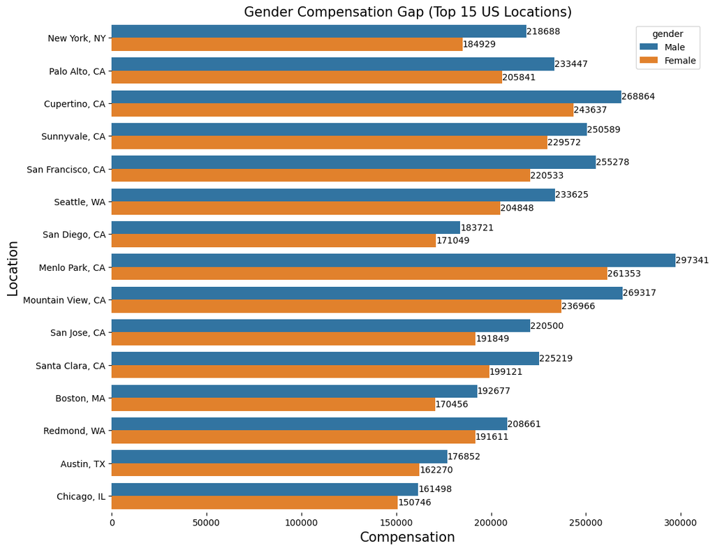

```
Average compensation gap by job location:

New York, NY : 33759
Palo Alto, CA : 27606
Cupertino, CA : 25227
Sunnyvale, CA : 21017
San Francisco, CA : 34745
Seattle, WA : 28776
San Diego, CA : 12672
Menlo Park, CA : 35987
Mountain View, CA : 32351
San Jose, CA : 28651
Santa Clara, CA : 26098
Boston, MA : 22222
Redmond, WA : 17049
Austin, TX : 14582
Chicago, IL : 10752
```

```python
df_top15 = df[df.location.isin(('Seattle, WA','San Francisco, CA','New York, NY','Redmond, WA','Sunnyvale, CA','Mountain View, CA','San Jose, CA','Austin, TX',\
                                'Menlo Park, CA','Cupertino, CA','Boston, MA','Santa Clara, CA','Palo Alto, CA','Chicago, IL','San Diego, CA'))]

plt.figure(figsize=(12, 10))
ax = sns.barplot(x="totalyearlycompensation", y="location", hue="gender", data=df_top15, errorbar=('ci', 0))
for container in ax.containers:
    ax.bar_label(container, fmt='%.f')
plt.title("Gender Compensation Gap (Top 15 US Locations)", size=15)
plt.xlabel("Compensation", size=15)
plt.ylabel("Location", size=15)
plt.xticks(fontsize=10)
sns.despine(left = True, bottom = True)
plt.show()



print("\nAverage compensation gap by job location:\n")

for spec_location in df_top15.location.unique():
    difference = (df_top15[(df_top15.location == spec_location) & (df_top15.gender == 'Male')].totalyearlycompensation.mean()) - \
                    (df_top15[(df_top15.location == spec_location) & (df_top15.gender == 'Female')].totalyearlycompensation.mean())
    print(f'{spec_location} : {int(difference.round())}')
```

And indeed, on average, women have a lower income regardless of the company or the position they work for, of course there are certain fluctuations due to the specifics of those same companies or positions.

But the main question is whether this is enough to claim about the existence of gender discrimination in salaries? Actually, the answer is no, because mean values don't take into account factors like education or work experience, which undoubtedly affect results.

### Checking for a correlation of gender with other variables

```python
df['gender_Male'] = pd.get_dummies(df['gender'], prefix='gender')['gender_Male']
df['gender_Female'] = pd.get_dummies(df['gender'], prefix='gender')['gender_Female']
```

```python
vars = ['totalyearlycompensation','yearsofexperience','yearsatcompany','Masters_Degree','Bachelors_Degree','Doctorate_Degree',
       'Highschool','Some_College','gender_Male','gender_Female']
corr_matrix = df[vars].corr()
corr_matrix.style.background_gradient(cmap='coolwarm')
```

|  | totalyearlycompensation | yearsofexperience | yearsatcompany | Masters_Degree | Bachelors_Degree | Doctorate_Degree | Highschool | Some_College | gender_Male | gender_Female |
| --- | --- | --- | --- | --- | --- | --- | --- | --- | --- | --- |
| totalyearlycompensation | 1.000000 | 0.423833 | 0.126134 | 0.111028 | -0.175596 | 0.150757 | -0.001665 | -0.017314 | 0.079513 | -0.079513 |
| yearsofexperience | 0.423833 | 1.000000 | 0.517015 | 0.103651 | -0.103177 | -0.023265 | 0.012038 | 0.042372 | 0.058767 | -0.058767 |
| yearsatcompany | 0.126134 | 0.517015 | 1.000000 | 0.041684 | -0.039778 | -0.002745 | -0.007319 | 0.000629 | 0.040107 | -0.040107 |
| Masters_Degree | 0.111028 | 0.103651 | 0.041684 | 1.000000 | -0.857261 | -0.231882 | -0.095281 | -0.114157 | 0.003435 | -0.003435 |
| Bachelors_Degree | -0.175596 | -0.103177 | -0.039778 | -0.857261 | 1.000000 | -0.206068 | -0.076187 | -0.091280 | -0.028943 | 0.028943 |
| Doctorate_Degree | 0.150757 | -0.023265 | -0.002745 | -0.231882 | -0.206068 | 1.000000 | -0.022882 | -0.027415 | 0.035635 | -0.035635 |
| Highschool | -0.001665 | 0.012038 | -0.007319 | -0.095281 | -0.076187 | -0.022882 | 1.000000 | -0.010136 | 0.035672 | -0.035672 |
| Some_College | -0.017314 | 0.042372 | 0.000629 | -0.114157 | -0.091280 | -0.027415 | -0.010136 | 1.000000 | 0.020929 | -0.020929 |
| gender_Male | 0.079513 | 0.058767 | 0.040107 | 0.003435 | -0.028943 | 0.035635 | 0.035672 | 0.020929 | 1.000000 | -1.000000 |
| gender_Female | -0.079513 | -0.058767 | -0.040107 | -0.003435 | 0.028943 | -0.035635 | -0.035672 | -0.020929 | -1.000000 | 1.000000 |

From the correlation graph, it can be seen that men are positively correlated with earnings. It was also expected that salary is most correlated with years of experience, years in the company, and level of education. Therefore, before concluding that women receive less just because they are women, it is necessary to check the ratios in the years of experience, years in the company and education for men and women - compare the results for fixed factors.

### Dependence on years of experience for men and women

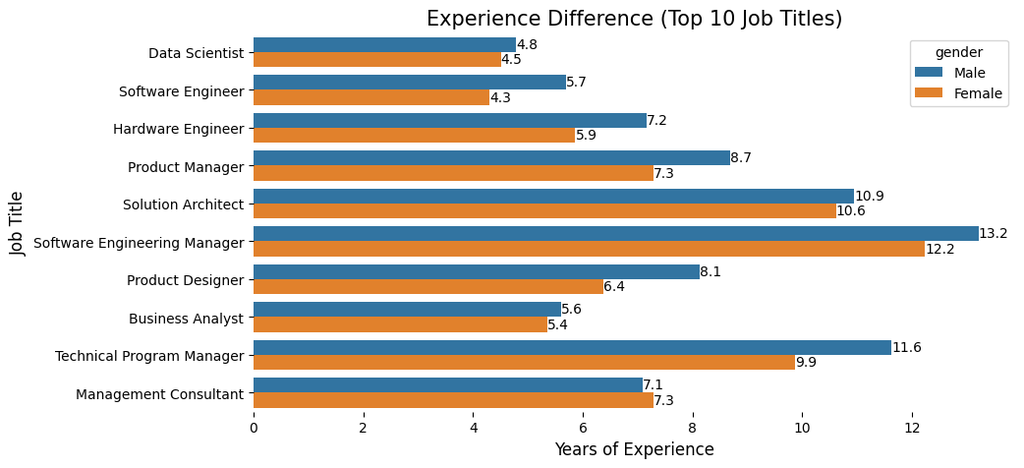

```
Average experience gap by job title:

Data Scientist : 0.3
Software Engineer : 1.4
Hardware Engineer : 1.3
Product Manager : 1.4
Solution Architect : 0.3
Software Engineering Manager : 1.0
Product Designer : 1.8
Business Analyst : 0.2
Technical Program Manager : 1.8
Management Consultant : -0.2
```

```python
plt.figure(figsize=(10, 5))
ax = sns.barplot(x="yearsofexperience", y="title", hue="gender", data=df_top10, errorbar=('ci', 0))
for container in ax.containers:
    ax.bar_label(container, fmt='%.1f')
plt.title("Experience Difference (Top 10 Job Titles)", size=15)
plt.xlabel("Years of Experience", size=12)
plt.ylabel("Job Title", size=12)
plt.xticks(fontsize=10)
sns.despine(left = True, bottom = True)
plt.show()

print("\nAverage experience gap by job title:\n")

for spec_title in df_top10.title.unique():
    difference = (df_top10[(df_top10.title == spec_title) & (df_top10.gender == 'Male')].yearsofexperience.mean()) - \
                    (df_top10[(df_top10.title == spec_title) & (df_top10.gender == 'Female')].yearsofexperience.mean())
    print(f'{spec_title} : {difference.round(1)}')
```

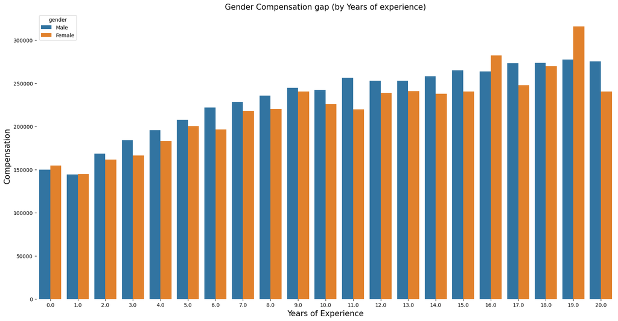

```python
decimals = 0
df['yearsofexperience'] = df['yearsofexperience'].apply(lambda x: round(x, decimals))

plt.figure(figsize=(20, 10))
ax = sns.barplot(y="totalyearlycompensation", x="yearsofexperience", hue="gender", data=df, errorbar=('ci', 0))
plt.title("Gender Compensation gap (by Years of experience)", size=15)
plt.xlabel("Years of Experience", size=15)
plt.ylabel("Compensation", size=15)
plt.xticks(fontsize=10)
sns.despine(left = True, bottom = True)
plt.show()
```

```python
# same but more clustered
clusters = []

for inx, row in df.iterrows():
    if 0 <= row['yearsofexperience'] <= 5:
        clusters.append('0-5')
    elif 6 <= row['yearsofexperience'] <= 12:
        clusters.append('6-12')
    elif 13 <= row['yearsofexperience']:
        clusters.append('13+')

df['exp_clustered'] = clusters
```

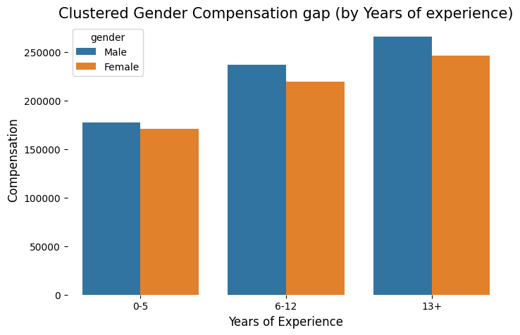

```python
plt.figure(figsize=(8, 5))
ax = sns.barplot(y="totalyearlycompensation", x="exp_clustered", hue="gender", data=df, errorbar=('ci', 0), order = df.groupby('exp_clustered').mean().sort_values('totalyearlycompensation').index)
plt.title("Clustered Gender Compensation gap (by Years of experience)", size = 15)
plt.xlabel("Years of Experience", size=12)
plt.ylabel("Compensation", size=12)
plt.xticks(fontsize=10)
sns.despine(left = True, bottom = True)
plt.show()
```

From the graphs above, it can be concluded that even without taking into account the fixed level of experience, in general, the salaries of women are generally lower than those of men, but it is also worth noting that there are cases when the gap is almost the same on average, or in favor of women. That is why, for more accurate results, we need to do the same manipulations and check the results for years in the company and level of education. But, since years of experience correlates quite strongly with the number of years with the company, we will not consider the difference in salary depending on the number of years with the company.

### Dependence on education level for men and women

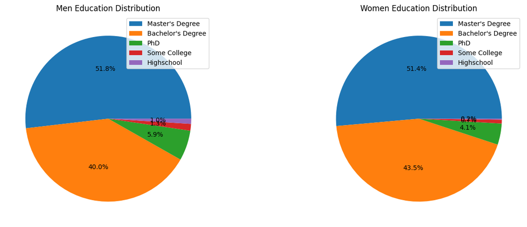

```python
men_educ = df[df.gender=='Male'].Education.value_counts()
women_educ = df[df.gender=='Female'].Education.value_counts()

men_educ = dict(men_educ)
men_degrees = list(men_educ.keys())
men_counts = list(men_educ.values())

women_educ = dict(women_educ)
women_degrees = list(women_educ.keys())
women_counts = list(women_educ.values())

fig, axes = plt.subplots(1, 2, figsize=(15, 5))

axes[0].pie(men_counts, labels=['']*len(men_degrees), autopct='%1.1f%%')
axes[0].set_title('Men Education Distribution')
axes[0].legend(men_degrees, loc="upper right")

axes[1].pie(women_counts, labels=['']*len(women_degrees), autopct='%1.1f%%')
axes[1].set_title('Women Education Distribution')
axes[1].legend(women_degrees, loc="upper right")

plt.tight_layout()

plt.show()
```

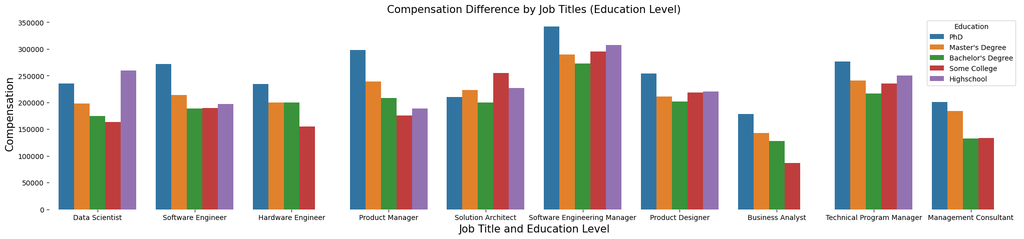

```python
plt.figure(figsize=(25, 5))
ax = sns.barplot(y="totalyearlycompensation", x="title", hue="Education", data=df_top10, errorbar=('ci', 0))

plt.title("Compensation Difference by Job Titles (Education Level)", size=15)
plt.xlabel("Job Title and Education Level", size=15)
plt.ylabel("Compensation", size=15)
plt.xticks(fontsize=10)
sns.despine(left = True, bottom = True)
plt.show()
```

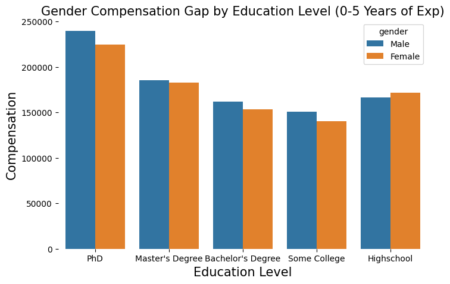

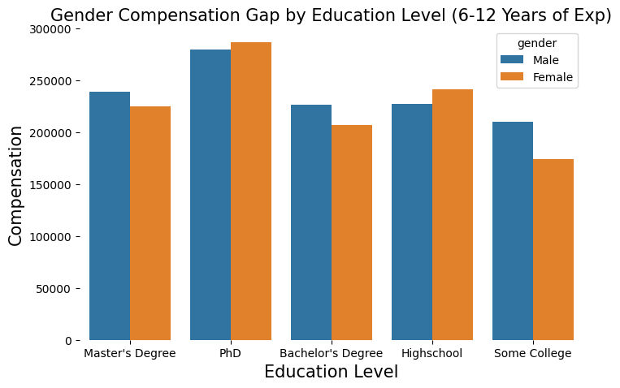

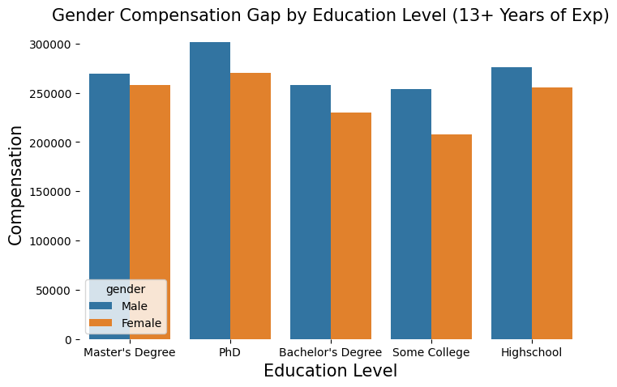

```python
plt.figure(figsize=(8, 5))
ax = sns.barplot(y="totalyearlycompensation", x="Education", hue="gender", data=df[df.exp_clustered=='0-5'], errorbar=('ci', 0))
plt.title("Gender Compensation Gap by Education Level (0-5 Years of Exp)", size=15)
plt.xlabel("Education Level", size=15)
plt.ylabel("Compensation", size=15)
plt.xticks(fontsize=10)
sns.despine(left = True, bottom = True)
plt.show()
print()

plt.figure(figsize=(8, 5))
ax = sns.barplot(y="totalyearlycompensation", x="Education", hue="gender", data=df[df.exp_clustered=='6-12'], errorbar=('ci', 0))
plt.title("Gender Compensation Gap by Education Level (6-12 Years of Exp)", size=15)
plt.xlabel("Education Level", size=15)
plt.ylabel("Compensation", size=15)
plt.xticks(fontsize=10)
sns.despine(left = True, bottom = True)
plt.show()
print()

plt.figure(figsize=(8, 5))
ax = sns.barplot(y="totalyearlycompensation", x="Education", hue="gender", data=df[df.exp_clustered=='13+'], errorbar=('ci', 0))
plt.title("Gender Compensation Gap by Education Level (13+ Years of Exp)", size=15)
plt.xlabel("Education Level", size=15)
plt.ylabel("Compensation", size=15)
plt.xticks(fontsize=10)
sns.despine(left = True, bottom = True)
plt.show()
```

What we see is a gender gap for 0-5 years of experiense being almost equall for all education levels(with a little loss for women). For 6-12 years of experience, gender gap becomes more random(with high compensation for women with Phd and much lower for College) - but generally, men are still in win. For 13+ years of experience, statistics drops dramatically - women start to earn less.

## Conclusion

After fixing the experience levels and observing the gender compensation difference for the particular levels of education, we are now able do state that women on average receive less due to the gender discrimination or some other unobserved factors(e.g. biological features, resistance to overloads or work experience)

# Race Discrimination

```python
df = pd.read_csv("/content/cloned_repo/Levels_Fyi_Salary_Data.csv")
```

```python
df['timestamp'] = pd.to_datetime(df['timestamp'])
df['timestamp'] = np.sort(df['timestamp'])
```

```python
pattern = r"^(?!.*,.*,).*$"
USA_paterned = [element for element in df['location'].unique() if re.search(pattern, element)]
USA = [element for element in USA_paterned if len(element.split(',')) == 2]

df = df[df['location'].isin(USA)]
```

```python
def remove_outliers():
    q1 = df['totalyearlycompensation'].quantile(0.25)
    q3 = df['totalyearlycompensation'].quantile(0.75)
    iqr = q3-q1
    left_boundary = q1 - 1.5*iqr
    right_boundary = q3 + 1.5*iqr
    df_pre = df[(df['totalyearlycompensation'] > left_boundary)\
                    & (df['totalyearlycompensation'] < right_boundary)]

    q1 = df_pre['yearsofexperience'].quantile(0.25)
    q3 = df_pre['yearsofexperience'].quantile(0.75)
    iqr = q3-q1
    left_boundary = q1 - 1.5*iqr
    right_boundary = q3 + 1.5*iqr
    df_out = df_pre[(df_pre['yearsofexperience'] > left_boundary)\
                    & (df_pre['yearsofexperience'] < right_boundary)]

    return df_out
```

```python
df = remove_outliers()
```

## Race Distribution

```python
df['Race'].unique()
```

```
array([nan, 'White', 'Asian', 'Black', 'Two Or More', 'Hispanic'],
      dtype=object)
```

```python
f = df.fillna({'Race':'Unknown'})
```

```python
race_counts = df['Race'].value_counts()
race_counts
```

```
Asian          8472
White          5779
Hispanic        905
Two Or More     628
Black           594
Name: Race, dtype: int64
```

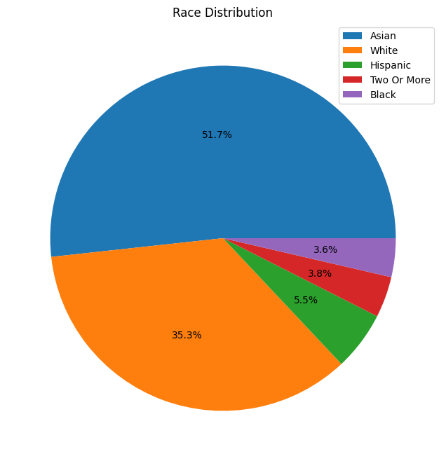

```python
race_counts = dict(race_counts)

races = list(race_counts.keys())
counts = list(race_counts.values())

plt.figure(figsize=(8, 8))
plt.pie(counts, labels=['']*len(races), autopct='%1.1f%%')

plt.legend(races, loc="upper right")
plt.title("Race Distribution")
plt.show()
```

## Salary Distribution

```python
df = df[df.Race.isin(('Unknown','Two Or More')) == False]
df = df[df['Education'].notna()]
```

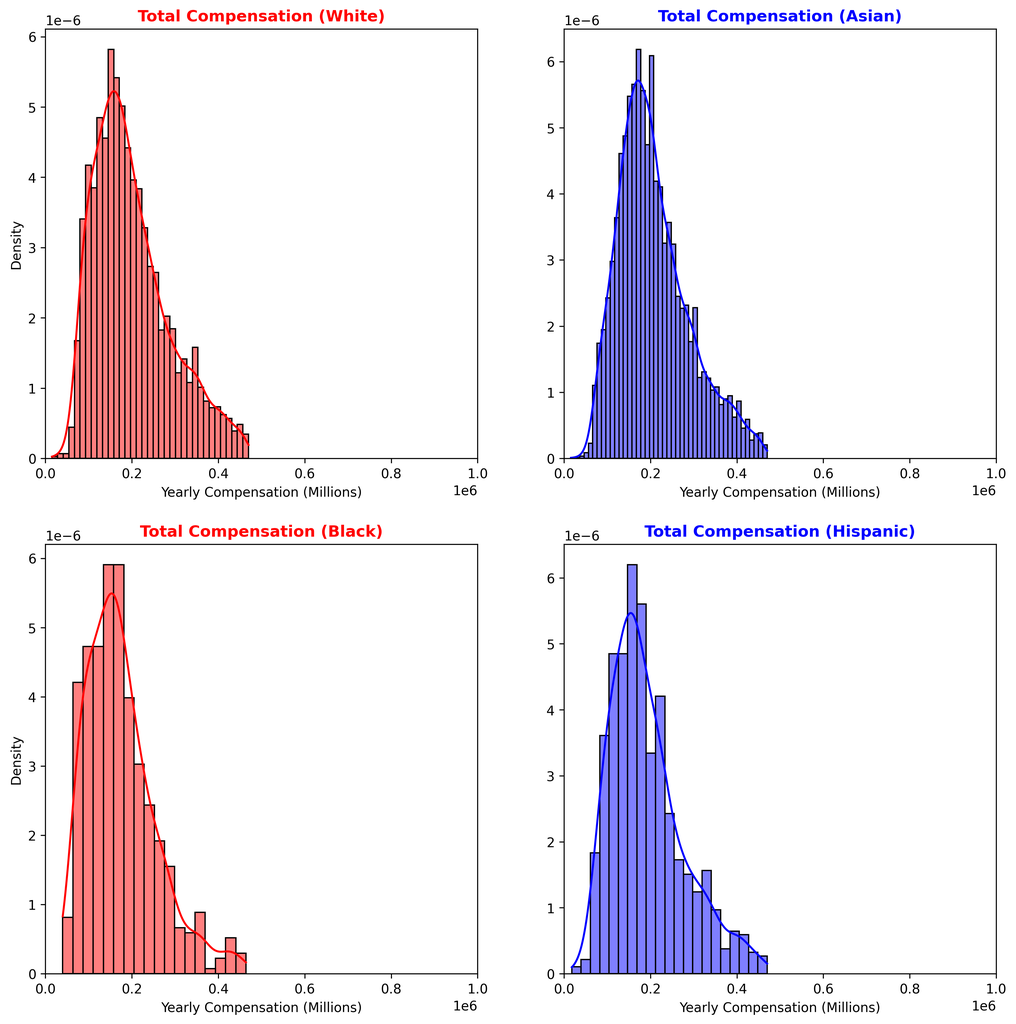

```python
fig, axis = plt.subplots(2, 2, figsize=(13,13), dpi=300)
sns.histplot(df[df['Race_White'] == 1].totalyearlycompensation.round(0), ax=axis[0,0], color="red", kde=True, stat="density", linewidth=1).set(xlim=(0, 1e6))
sns.histplot(df[df['Race_Asian'] == 1].totalyearlycompensation.round(0), ax=axis[0,1], color="blue", kde=True, stat="density", linewidth=1).set(xlim=(0, 1e6))
axis[0,0].set_title("Total Compensation (White)", fontweight="bold", color="red")
axis[0,0].set_xlabel('Yearly Compensation (Millions)')
axis[0,1].set_title("Total Compensation (Asian)", fontweight="bold", color="blue")
axis[0,1].set_xlabel('Yearly Compensation (Millions)')
axis[0,1].set_ylabel('');

sns.histplot(df[df['Race_Black'] == 1].totalyearlycompensation.round(0), ax=axis[1,0], color="red", kde=True, stat="density", linewidth=1).set(xlim=(0, 1e6))
sns.histplot(df[df['Race_Hispanic'] == 1].totalyearlycompensation.round(0), ax=axis[1,1], color="blue", kde=True, stat="density", linewidth=1).set(xlim=(0, 1e6))
axis[1,0].set_title("Total Compensation (Black)", fontweight="bold", color="red")
axis[1,0].set_xlabel('Yearly Compensation (Millions)')
axis[1,1].set_title("Total Compensation (Hispanic)", fontweight="bold", color="blue")
axis[1,1].set_xlabel('Yearly Compensation (Millions)')
axis[1,1].set_ylabel('');
```

```python
def run_ks_test(ser1, ser2):
    alternatives = ['F(x) != G(X)', 'F(x) < G(x)', 'F(x) > G(x)']
    p1 = ks_2samp(ser1, ser2).pvalue
    p2 = ks_2samp(ser1, ser2, alternative='less').pvalue
    p3 = ks_2samp(ser1, ser2, alternative='greater').pvalue
    tests = [round(p1, 5), round(p2, 5), round(p3,5)]

    output_df = pd.DataFrame({'Test': alternatives,
                  'P-value': tests})
    return output_df
```

```python
run_ks_test(df[df['Race']=='Asian'].totalyearlycompensation, df[df['Race']=='White'].totalyearlycompensation)
```

|  | Test | P-value |
| --- | --- | --- |
| 0 | F(x) != G(X) | 0.00000 |
| 1 | F(x) < G(x) | 0.00000 |
| 2 | F(x) > G(x) | 0.44833 |

```python
run_ks_test(df[df['Race']=='Asian'].totalyearlycompensation, df[df['Race']=='Black'].totalyearlycompensation)
```

|  | Test | P-value |
| --- | --- | --- |
| 0 | F(x) != G(X) | 0.00000 |
| 1 | F(x) < G(x) | 0.00000 |
| 2 | F(x) > G(x) | 0.99395 |

```python
run_ks_test(df[df['Race']=='Asian'].totalyearlycompensation, df[df['Race']=='Hispanic'].totalyearlycompensation)
```

|  | Test | P-value |
| --- | --- | --- |
| 0 | F(x) != G(X) | 0.00000 |
| 1 | F(x) < G(x) | 0.00000 |
| 2 | F(x) > G(x) | 0.98919 |

```python
run_ks_test(df[df['Race']=='White'].totalyearlycompensation, df[df['Race']=='Hispanic'].totalyearlycompensation)
```

|  | Test | P-value |
| --- | --- | --- |
| 0 | F(x) != G(X) | 0.08261 |
| 1 | F(x) < G(x) | 0.04131 |
| 2 | F(x) > G(x) | 0.99752 |

```python
run_ks_test(df[df['Race']=='White'].totalyearlycompensation, df[df['Race']=='Black'].totalyearlycompensation)
```

|  | Test | P-value |
| --- | --- | --- |
| 0 | F(x) != G(X) | 0.0000 |
| 1 | F(x) < G(x) | 0.0000 |
| 2 | F(x) > G(x) | 0.9985 |

```python
run_ks_test(df[df['Race']=='Hispanic'].totalyearlycompensation, df[df['Race']=='Black'].totalyearlycompensation)
```

|  | Test | P-value |
| --- | --- | --- |
| 0 | F(x) != G(X) | 0.01187 |
| 1 | F(x) < G(x) | 0.00591 |
| 2 | F(x) > G(x) | 0.99167 |

## Salary Dispercity

```python
df[df['Race'] == 'Asian'].totalyearlycompensation.mean().round()
```

```
207853.0
```

```python
df[df['Race'] == 'White'].totalyearlycompensation.mean().round()
```

```
199573.0
```

```python
df[df['Race'] == 'Hispanic'].totalyearlycompensation.mean().round()
```

```
192051.0
```

```python
df[df['Race'] == 'Black'].totalyearlycompensation.mean().round()
```

```
174932.0
```

### Top 5 Companies

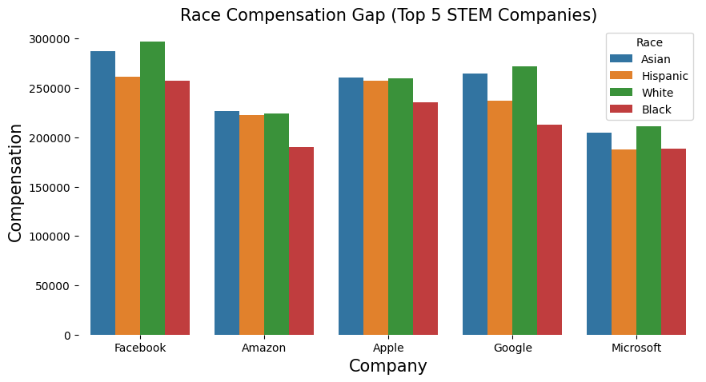

```python
df_top5 = df[df.company.isin(['Amazon','Microsoft','Google','Facebook','Apple'])]

plt.figure(figsize=(10, 5))
sns.barplot(x="company", y="totalyearlycompensation", hue="Race", data=df_top5, errorbar=('ci', 0))
plt.title("Race Compensation Gap (Top 5 STEM Companies)", size=15)
plt.xlabel("Company", size=15)
plt.ylabel("Compensation", size=15)
plt.xticks(fontsize=10)
sns.despine(left = True, bottom = True)
plt.show()
```

### Top 10 Job Titles

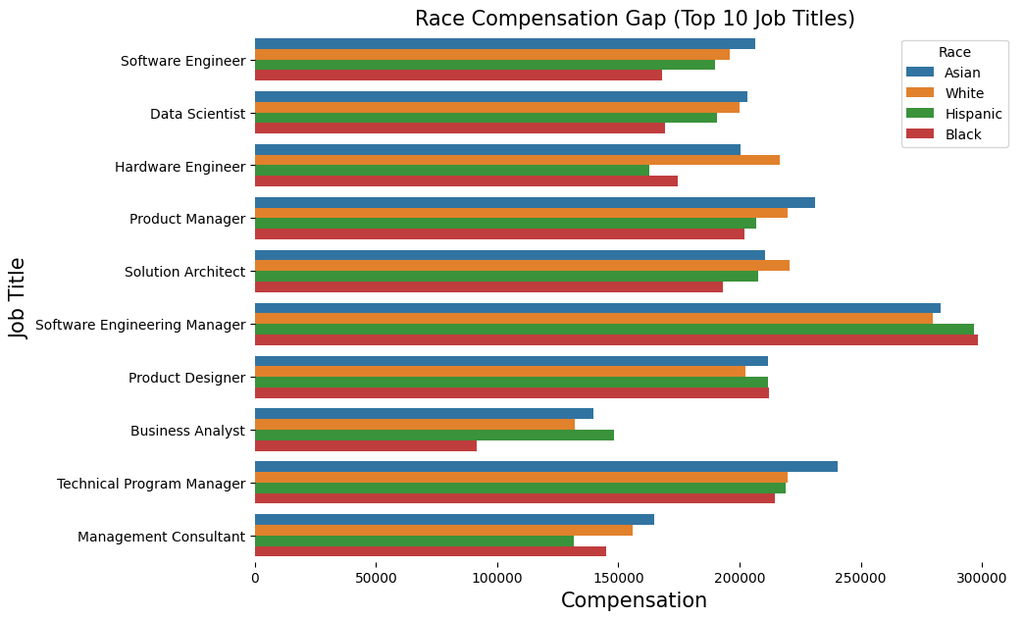

```python
df_top10 = df[df.title.isin(('Software Engineer','Product Manager','Software Engineering Manager'\
                             ,'Data Scientist','Hardware Engineer', 'Product Designer','Technical Program Manager','Solution Architect'\
                             ,'Management Consultant','Business Analyst'))]

plt.figure(figsize=(10, 7))
ax = sns.barplot(x="totalyearlycompensation", y="title", hue="Race", data=df_top10, errorbar=('ci', 0))
plt.title("Race Compensation Gap (Top 10 Job Titles)", size=15)
plt.xlabel("Compensation", size=15)
plt.ylabel("Job Title", size=15)
plt.xticks(fontsize=10)
sns.despine(left = True, bottom = True)
plt.show()
```

### Top 15 locations

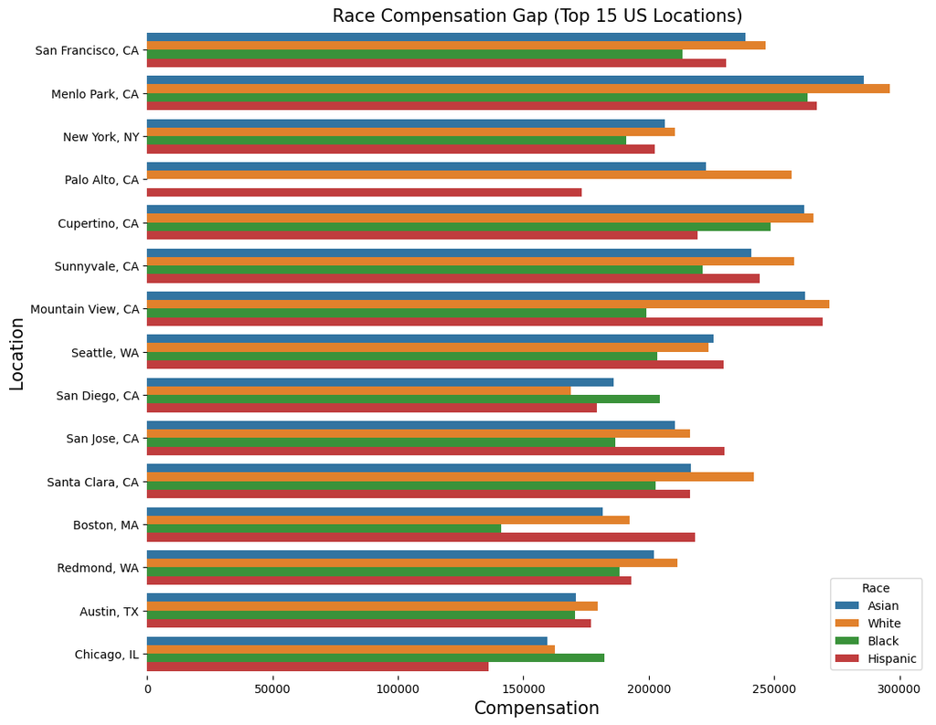

```python
df_top15 = df[df.location.isin(('Seattle, WA','San Francisco, CA','New York, NY','Redmond, WA','Sunnyvale, CA','Mountain View, CA','San Jose, CA','Austin, TX',\
                                'Menlo Park, CA','Cupertino, CA','Boston, MA','Santa Clara, CA','Palo Alto, CA','Chicago, IL','San Diego, CA'))]

plt.figure(figsize=(12, 10))
ax = sns.barplot(x="totalyearlycompensation", y="location", hue="Race", data=df_top15, errorbar=('ci', 0))
plt.title("Race Compensation Gap (Top 15 US Locations)", size=15)
plt.xlabel("Compensation", size=15)
plt.ylabel("Location", size=15)
plt.xticks(fontsize=10)
sns.despine(left = True, bottom = True)
plt.show()
```

### Checking for a correlation of Race with other variables

```python
df['gender_Male'] = pd.get_dummies(df['gender'], prefix='gender')['gender_Male']
df['gender_Female'] = pd.get_dummies(df['gender'], prefix='gender')['gender_Female']
```

```python
vars = ['totalyearlycompensation','yearsofexperience','yearsatcompany','Masters_Degree','Bachelors_Degree','Doctorate_Degree',
       'Highschool','Some_College','gender_Male','Race_White','Race_Asian','Race_Black','Race_Hispanic']
corr_matrix = df[vars].corr()
corr_matrix.style.background_gradient(cmap='coolwarm')
```

|  | totalyearlycompensation | yearsofexperience | yearsatcompany | Masters_Degree | Bachelors_Degree | Doctorate_Degree | Highschool | Some_College | gender_Male | Race_White | Race_Asian | Race_Black | Race_Hispanic |
| --- | --- | --- | --- | --- | --- | --- | --- | --- | --- | --- | --- | --- | --- |
| totalyearlycompensation | 1.000000 | 0.422712 | 0.123371 | 0.112571 | -0.184013 | 0.157447 | -0.002230 | -0.018934 | 0.032958 | -0.064265 | -0.010843 | -0.065257 | -0.040172 |
| yearsofexperience | 0.422712 | 1.000000 | 0.515198 | 0.107392 | -0.104232 | -0.026616 | 0.015177 | 0.035419 | 0.035147 | 0.062638 | -0.066469 | -0.030072 | -0.008165 |
| yearsatcompany | 0.123371 | 0.515198 | 1.000000 | 0.041045 | -0.039644 | -0.003350 | -0.003836 | 0.000731 | 0.037020 | 0.055643 | -0.031136 | -0.044861 | -0.014623 |
| Masters_Degree | 0.112571 | 0.107392 | 0.041045 | 1.000000 | -0.851123 | -0.251675 | -0.095701 | -0.110573 | -0.027352 | -0.315384 | 0.090988 | -0.073633 | -0.109434 |
| Bachelors_Degree | -0.184013 | -0.104232 | -0.039644 | -0.851123 | 1.000000 | -0.206559 | -0.071068 | -0.082112 | 0.016941 | 0.298201 | -0.051283 | 0.077727 | 0.112750 |
| Doctorate_Degree | 0.157447 | -0.026616 | -0.003350 | -0.251675 | -0.206559 | 1.000000 | -0.023205 | -0.026812 | 0.001315 | -0.031249 | -0.054087 | -0.027262 | -0.020623 |
| Highschool | -0.002230 | 0.015177 | -0.003836 | -0.095701 | -0.071068 | -0.023205 | 1.000000 | -0.009225 | 0.033012 | 0.082414 | -0.044743 | 0.014257 | 0.024187 |
| Some_College | -0.018934 | 0.035419 | 0.000731 | -0.110573 | -0.082112 | -0.026812 | -0.009225 | 1.000000 | 0.030870 | 0.104636 | -0.057762 | 0.036002 | 0.018099 |
| gender_Male | 0.032958 | 0.035147 | 0.037020 | -0.027352 | 0.016941 | 0.001315 | 0.033012 | 0.030870 | 1.000000 | 0.104553 | 0.101958 | 0.001976 | 0.051290 |
| Race_White | -0.064265 | 0.062638 | 0.055643 | -0.315384 | 0.298201 | -0.031249 | 0.082414 | 0.104636 | 0.104553 | 1.000000 | -0.447539 | -0.094712 | -0.116746 |
| Race_Asian | -0.010843 | -0.066469 | -0.031136 | 0.090988 | -0.051283 | -0.054087 | -0.044743 | -0.057762 | 0.101958 | -0.447539 | 1.000000 | -0.126262 | -0.155151 |
| Race_Black | -0.065257 | -0.030072 | -0.044861 | -0.073633 | 0.077727 | -0.027262 | 0.014257 | 0.036002 | 0.001976 | -0.094712 | -0.126262 | 1.000000 | -0.032937 |
| Race_Hispanic | -0.040172 | -0.008165 | -0.014623 | -0.109434 | 0.112750 | -0.020623 | 0.024187 | 0.018099 | 0.051290 | -0.116746 | -0.155151 | -0.032937 | 1.000000 |

** years at company will be omitted because it higly correlates with years at company(same as we did for gender)

### Dependence on Years of Experience for Races

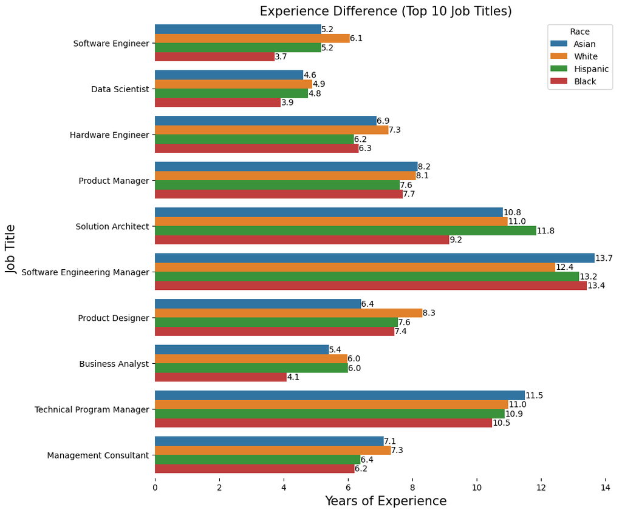

```python
plt.figure(figsize=(10, 10))
ax = sns.barplot(x="yearsofexperience", y="title", hue="Race", data=df_top10, errorbar=('ci', 0))
for container in ax.containers:
    ax.bar_label(container, fmt='%.1f')
plt.title("Experience Difference (Top 10 Job Titles)", size=15)
plt.xlabel("Years of Experience", size=15)
plt.ylabel("Job Title", size=15)
plt.xticks(fontsize=10)
sns.despine(left = True, bottom = True)
plt.show()
```

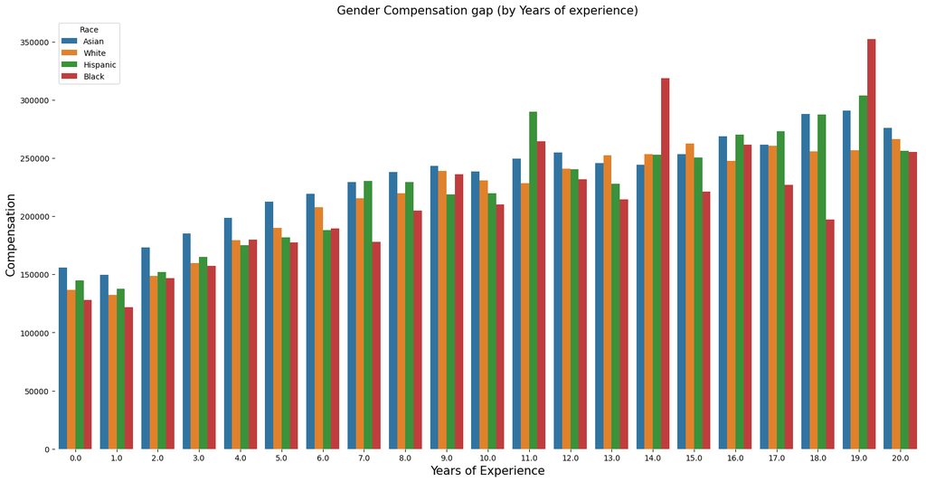

```python
decimals = 0
df['yearsofexperience'] = df['yearsofexperience'].apply(lambda x: round(x, decimals))

plt.figure(figsize=(20, 10))
ax = sns.barplot(y="totalyearlycompensation", x="yearsofexperience", hue="Race", data=df, errorbar=('ci', 0))
plt.title("Gender Compensation gap (by Years of experience)", size=15)
plt.xlabel("Years of Experience", size=15)
plt.ylabel("Compensation", size=15)
plt.xticks(fontsize=10)
sns.despine(left = True, bottom = True)
plt.show()
```

```python
clusters = []

for inx, row in df.iterrows():
    if 0 <= row['yearsofexperience'] <= 5:
        clusters.append('0-5')
    elif 6 <= row['yearsofexperience'] <= 12:
        clusters.append('6-12')
    elif 13 <= row['yearsofexperience']:
        clusters.append('13+')

df['exp_clustered'] = clusters
```

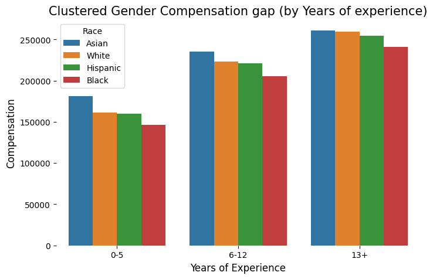

```python
plt.figure(figsize=(8, 5))
ax = sns.barplot(y="totalyearlycompensation", x="exp_clustered", hue="Race", data=df, errorbar=('ci', 0), order = df.groupby('exp_clustered').mean().sort_values('totalyearlycompensation').index)
plt.title("Clustered Gender Compensation gap (by Years of experience)", size = 15)
plt.xlabel("Years of Experience", size=12)
plt.ylabel("Compensation", size=12)
plt.xticks(fontsize=10)
sns.despine(left = True, bottom = True)
plt.show()
```

### Dependence on Education Level for Races

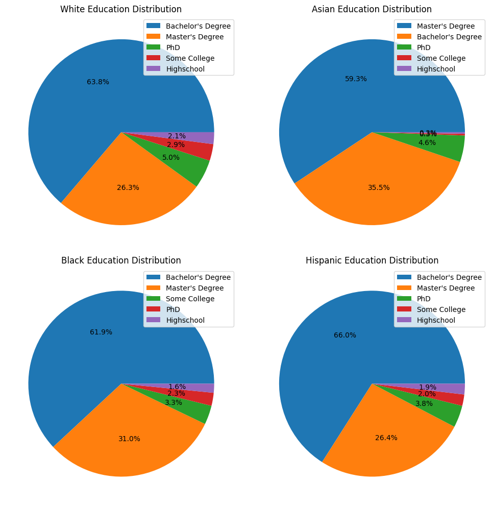

```python
white_educ = df[df.Race=='White'].Education.value_counts()
asian_educ = df[df.Race=='Asian'].Education.value_counts()
black_educ = df[df.Race=='Black'].Education.value_counts()
hispanic_educ = df[df.Race=='Hispanic'].Education.value_counts()

white_educ = dict(white_educ)
white_degrees = list(white_educ.keys())
white_counts = list(white_educ.values())

asian_educ = dict(asian_educ)
asian_degrees = list(asian_educ.keys())
asian_counts = list(asian_educ.values())

black_educ = dict(black_educ)
black_degrees = list(black_educ.keys())
black_counts = list(black_educ.values())

hispanic_educ = dict(hispanic_educ)
hispanic_degrees = list(hispanic_educ.keys())
hispanic_counts = list(hispanic_educ.values())


fig, axes = plt.subplots(2, 2, figsize=(10, 10))

axes[0, 0].pie(white_counts, labels=['']*len(white_degrees), autopct='%1.1f%%')
axes[0, 0].set_title('White Education Distribution')
axes[0, 0].legend(white_degrees, loc="upper right")

axes[0, 1].pie(asian_counts, labels=['']*len(asian_degrees), autopct='%1.1f%%')
axes[0, 1].set_title('Asian Education Distribution')
axes[0, 1].legend(asian_degrees, loc="upper right")

axes[1, 0].pie(black_counts, labels=['']*len(black_degrees), autopct='%1.1f%%')
axes[1, 0].set_title('Black Education Distribution')
axes[1, 0].legend(black_degrees, loc="upper right")

axes[1, 1].pie(hispanic_counts, labels=['']*len(hispanic_degrees), autopct='%1.1f%%')
axes[1, 1].set_title('Hispanic Education Distribution')
axes[1, 1].legend(hispanic_degrees, loc="upper right")


plt.tight_layout()

plt.show()
```

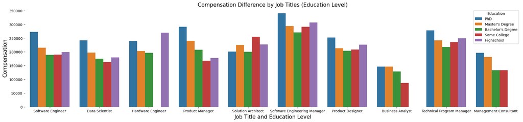

```python
plt.figure(figsize=(25, 5))
ax = sns.barplot(y="totalyearlycompensation", x="title", hue="Education", data=df_top10, errorbar=('ci', 0))

plt.title("Compensation Difference by Job Titles (Education Level)", size=15)
plt.xlabel("Job Title and Education Level", size=15)
plt.ylabel("Compensation", size=15)
plt.xticks(fontsize=10)
sns.despine(left = True, bottom = True)
plt.show()
```

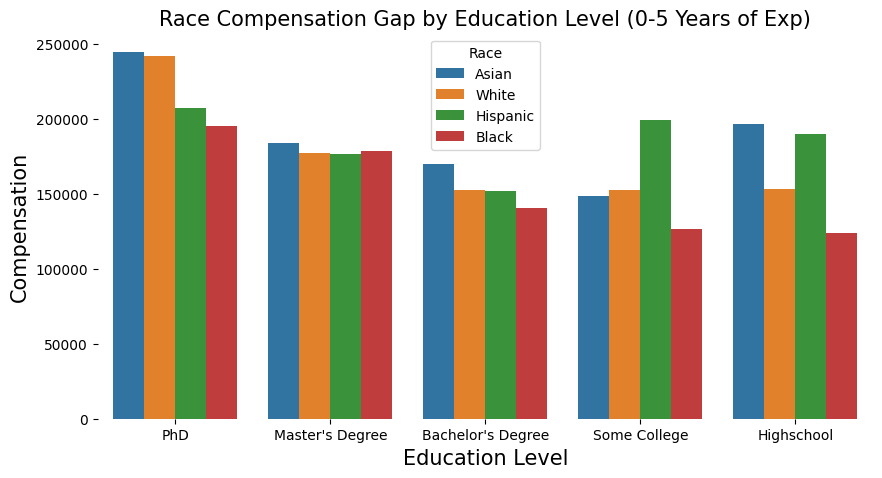

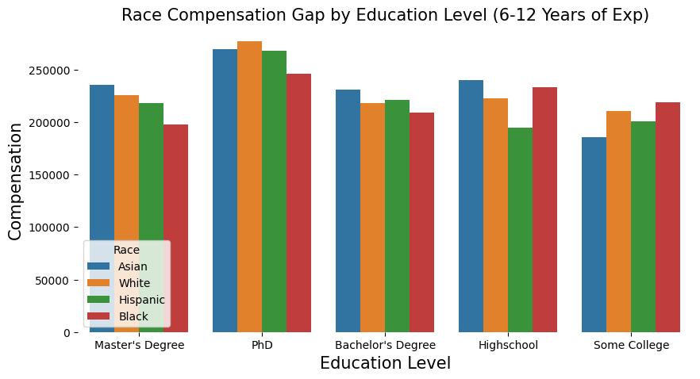

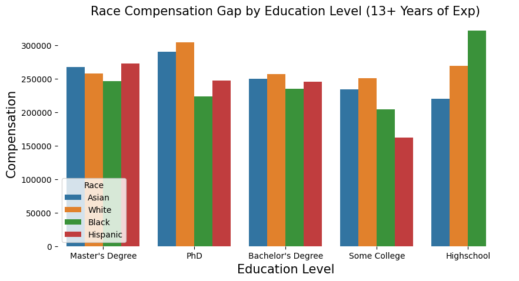

```python
plt.figure(figsize=(10, 5))
ax = sns.barplot(y="totalyearlycompensation", x="Education", hue="Race", data=df[df.exp_clustered=='0-5'], errorbar=('ci', 0))
plt.title("Race Compensation Gap by Education Level (0-5 Years of Exp)", size=15)
plt.xlabel("Education Level", size=15)
plt.ylabel("Compensation", size=15)
plt.xticks(fontsize=10)
sns.despine(left = True, bottom = True)
plt.show()
print()

plt.figure(figsize=(10, 5))
ax = sns.barplot(y="totalyearlycompensation", x="Education", hue="Race", data=df[df.exp_clustered=='6-12'], errorbar=('ci', 0))
plt.title("Race Compensation Gap by Education Level (6-12 Years of Exp)", size=15)
plt.xlabel("Education Level", size=15)
plt.ylabel("Compensation", size=15)
plt.xticks(fontsize=10)
sns.despine(left = True, bottom = True)
plt.show()
print()

plt.figure(figsize=(10, 5))
ax = sns.barplot(y="totalyearlycompensation", x="Education", hue="Race", data=df[df.exp_clustered=='13+'], errorbar=('ci', 0))
plt.title("Race Compensation Gap by Education Level (13+ Years of Exp)", size=15)
plt.xlabel("Education Level", size=15)
plt.ylabel("Compensation", size=15)
plt.xticks(fontsize=10)
sns.despine(left = True, bottom = True)
plt.show()
```

## Conclusion

After fixing the experience levels and observing the race compensation difference for the particular levels of education, you could observe that we are not able to draw any conclusions about race discrimination at some level of eexperience, company or job title. It's easy to see that Black and Hispanic people tend to vary in the size of compensation for different experience/education/title. The reason for that is not a discrimination - it's a sample size being not big enough to segment it that hard and to derrive accurate conclusions. We can easily see that for White people and Asians (taking almost 90% of a sample), for different distributions of experience, education and other relevant factors, both races possess not that random compensation values - disturbance of compensation does not change. Of course this is just one dataset with its own biases and disproportions among different groups.

# OLS

```python
y = df['totalyearlycompensation']
x = df[['yearsofexperience','yearsatcompany', 'Bachelors_Degree', 'Doctorate_Degree',
        'Some_College','Race_White','Race_Asian','Race_Hispanic','gender_Male']]
x = sm.add_constant(x)
model = sm.OLS(y, x).fit()

print(model.summary())
```

```
                               OLS Regression Results
===================================================================================
Dep. Variable:     totalyearlycompensation   R-squared:                       0.237
Model:                                 OLS   Adj. R-squared:                  0.237
Method:                      Least Squares   F-statistic:                     762.4
Date:                     Tue, 23 May 2023   Prob (F-statistic):               0.00
Time:                             19:42:11   Log-Likelihood:            -2.7926e+05
No. Observations:                    22094   AIC:                         5.585e+05
Df Residuals:                        22084   BIC:                         5.586e+05
Df Model:                                9
Covariance Type:                 nonrobust
=====================================================================================
                        coef    std err          t      P>|t|      [0.025      0.975]
-------------------------------------------------------------------------------------
const              1.686e+05   1341.662    125.690      0.000    1.66e+05    1.71e+05
yearsofexperience  8250.0052    117.459     70.237      0.000    8019.777    8480.233
yearsatcompany    -3684.3898    196.406    -18.759      0.000   -4069.360   -3299.420
Bachelors_Degree  -1.523e+04   1147.380    -13.277      0.000   -1.75e+04    -1.3e+04
Doctorate_Degree   5.158e+04   2121.259     24.318      0.000    4.74e+04    5.57e+04
Some_College      -2.798e+04   4995.444     -5.600      0.000   -3.78e+04   -1.82e+04
Race_White        -1.415e+04   1451.104     -9.749      0.000    -1.7e+04   -1.13e+04
Race_Asian        -3987.5948   1231.992     -3.237      0.001   -6402.388   -1572.802
Race_Hispanic     -1.692e+04   2755.403     -6.139      0.000   -2.23e+04   -1.15e+04
gender_Male        6606.1149   1150.103      5.744      0.000    4351.831    8860.399
==============================================================================
Omnibus:                     1666.654   Durbin-Watson:                   1.964
Prob(Omnibus):                  0.000   Jarque-Bera (JB):             2082.070
Skew:                           0.711   Prob(JB):                         0.00
Kurtosis:                       3.491   Cond. No.                         88.4
==============================================================================

Notes:
[1] Standard Errors assume that the covariance matrix of the errors is correctly specified.
```

# Covid-19 impact

## Data selection

```python
df = pd.read_csv("/content/cloned_repo/Levels_Fyi_Salary_Data.csv")
```

```python
df['timestamp'] = pd.to_datetime(df['timestamp'])
df['timestamp'] = np.sort(df['timestamp'])
df.index = pd.to_datetime(df['timestamp'])
```

```python
df = df[df['title'] == 'Software Engineer']
df = df[df['gender']!='Other']
df['days_from_start_of_recording'] = (df['timestamp'] - df['timestamp'].min()).dt.days
df['gender_Male'] = pd.get_dummies(df['gender'], prefix='gender')['gender_Male'];
```

```python
pattern = r"^(?!.*,.*,).*$"
USA_paterned = [element for element in df['location'].unique() if re.search(pattern, element)]
USA = [element for element in USA_paterned if len(element.split(',')) == 2]
df = df[df['location'].isin(USA)]
```

```python
inflation = pd.read_csv('/content/cloned_repo/united-states-inflation-rate-cpi.csv')
inflation = inflation.iloc[57:]
inflation['year'] = [2017, 2018, 2019, 2020, 2021]
inflation = inflation.set_index('year')
df['year'] = df.index.year
```

```python
inflation['inflation'] = 1+inflation[' Inflation Rate (%)']/100
inflation['inflation_comulative'] = 1
```

```python
inflation.iloc[0, inflation.columns.get_loc('inflation_comulative')] = inflation.iloc[0]['inflation']
inflation.iloc[1, inflation.columns.get_loc('inflation_comulative')] = inflation.iloc[1]['inflation']*inflation.iloc[0]['inflation_comulative']
inflation.iloc[2, inflation.columns.get_loc('inflation_comulative')] = inflation.iloc[2]['inflation']*inflation.iloc[1]['inflation_comulative']
inflation.iloc[3, inflation.columns.get_loc('inflation_comulative')] = inflation.iloc[3]['inflation']*inflation.iloc[2]['inflation_comulative']
inflation.iloc[4, inflation.columns.get_loc('inflation_comulative')] = inflation.iloc[4]['inflation']*inflation.iloc[3]['inflation_comulative']
```

```python
df['inflation'] = df['year'].map(inflation['inflation'])
df['inflation_comulative'] = df['year'].map(inflation['inflation_comulative'])
```

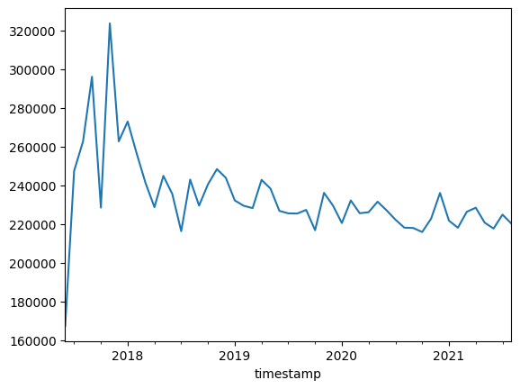

```python
avarege_by_month = df.resample('1M').mean()
avarege_by_month['totalyearlycompensation'].plot()
```

```python
df.reset_index(drop=True);
```